# Assignment 10: Predictive Modeling - Part 1

*How to do it?*:

- Open the Rmarkdown file of this assignment (link) in Rstudio.
- Right under each **question**, insert a code chunk (you can use the hotkey `Ctrl + Alt + I` to add a code chunk) and code the solution for the question.
- `Knit` the rmarkdown file (hotkey: `Ctrl + Alt + K`) to export an html.
- Publish the html file to your Githiub Page.

*Submission*: Submit the link on Github of the assignment to Canvas

1. Use the `Adult Census Income` dataset. We will predict the income (whether or not it is more than 50k or not) of an adult. Import the dataset. Partition the data into 80% training and 20% testing.

```r
library(tidyverse)
library(ggplot2)
library(caret)
setwd("C:/Users/student/Documents/Stat Analysis with R/MATH421")
df <- read_csv('adult_census.csv')
df = drop_na(df)
df <- df %>%
  mutate(income = as.factor(income), workclass = as.factor(workclass),
         education = as.factor(education),
         marital.status = as.factor(marital.status),
         occupation = as.factor(occupation), relationship = as.factor(relationship), race = as.factor(race), sex = as.factor(sex), native.country = as.factor(native.country)
         )

splitIndex <- createDataPartition(df$income, p = .80,
                                  list = FALSE)
df_train <- df[ splitIndex,]
df_test <- df[-splitIndex,]
```

2. Practice Decision Tree. Do the follows:
- Use `rpart` package, create a decision tree with maximum depth of 3.

```r
library(rpart)
tree_model <- rpart(income ~ ., data = df_train,
                 control = rpart.control(maxdepth = 3))
```

- Calculate the accuracy of the model on the testing data. Notice that the positive outcome here is not `1` but `>50K` or `<50K`.

```r
pred <- predict(tree_model, df_test, type = "class")
cm <- confusionMatrix(data = pred, reference = df_test$income)
cm$overall
```

```
##       Accuracy          Kappa  AccuracyLower  AccuracyUpper   AccuracyNull
##   8.421376e-01   5.145294e-01   8.330523e-01   8.509154e-01   7.592138e-01
## AccuracyPValue  McnemarPValue
##   1.324609e-60   2.535410e-56
```

- Plot the tree

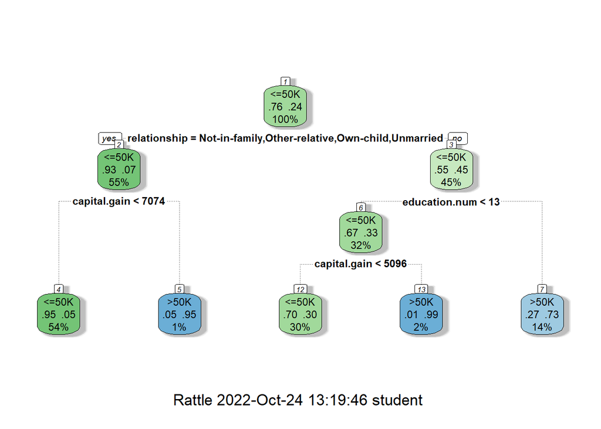

```r
library(rattle)
fancyRpartPlot(tree_model)
```

- Plot the variable importance by the tree

```r
tree_model$variable.importance
```

```
##   relationship marital.status   capital.gain  education.num            sex
##    1926.099263    1894.076576     799.780252     775.070446     600.261998
##     occupation            age hours.per.week native.country   capital.loss
##     556.270947     442.599279     247.358918      19.588975      15.888835
##           race
##       4.570761
```

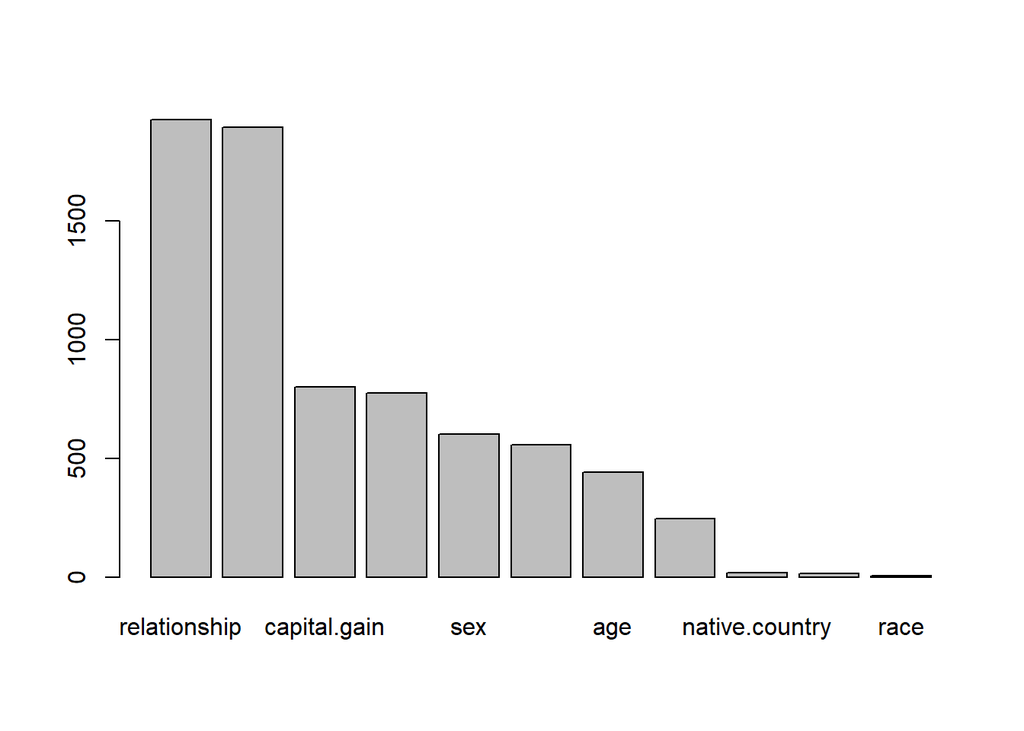

```r
barplot(tree_model$variable.importance)
```

3. Create 3 more trees and compare the testing accuracy of these trees, which tree give the highest testing accuracy.

```r
tree_model <- rpart(income ~ ., data = df_train,
                 control = rpart.control(maxdepth = 2))
pred <- predict(tree_model, df_test, type = "class")
cm <- confusionMatrix(data = pred, reference = df_test$income)
cm$overall
```

```
##       Accuracy          Kappa  AccuracyLower  AccuracyUpper   AccuracyNull
##   8.255528e-01   4.478456e-01   8.161137e-01   8.346994e-01   7.592138e-01
## AccuracyPValue  McnemarPValue
##   1.022384e-38   2.771619e-76
```